# HW2

# Q1:

## Part A

```r
# iso3c and country are both primary keys in this dataset
# after running summarize, only the grouped by columns and
# the new column created within summarize will exist in the resulting dataframe
country_population %>% filter((1990 <= year) & (year <= 2010)) %>%
  group_by(iso3c, country) %>%
  summarize(mean_population = mean(population))
```

```
#> # A tibble: 215 × 3
#> # Groups:   iso3c [215]
#>    iso3c country              mean_population
#>    <chr> <chr>                          <dbl>
#>  1 ABW   Aruba                         85839.
#>  2 AFG   Afghanistan                19819866.
#>  3 AGO   Angola                     16829911.
#>  4 ALB   Albania                     3095489.
#>  5 AND   Andorra                       67825.
#>  6 ARE   United Arab Emirates        3858774.
#>  7 ARG   Argentina                  36972314.
#>  8 ARM   Armenia                     3211816.
#>  9 ASM   American Samoa                54995.
#> 10 ATG   Antigua and Barbuda           74385.
#> # ℹ 205 more rows
```

## Part B

```r
country_birth %>% filter((1990 <= year) & (year <= 2010)) %>%
  dplyr::select(iso3c, year, life_expect) %>%
  na.omit() %>%
  group_by(iso3c) %>%
  summarize(max_life_expect = max(life_expect),
            min_life_expect = min(life_expect)) %>%
  mutate(range_life_expect = max_life_expect - min_life_expect)
```

```
#> # A tibble: 203 × 4
#>    iso3c max_life_expect min_life_expect range_life_expect
#>    <chr>           <dbl>           <dbl>             <dbl>
#>  1 ABW              75.0            73.4              1.56
#>  2 AFG              59.0            49.9              9.11
#>  3 AGO              50.7            41.1              9.52
#>  4 ALB              77.0            71.9              5.14
#>  5 ARE              76.7            71.7              4.96
#>  6 ARG              75.5            71.5              3.94
#>  7 ARM              74.2            67.7              6.49
#>  8 ATG              75.3            71.2              4.15
#>  9 AUS              81.7            77.0              4.70
#> 10 AUT              80.6            75.6              5.01
#> # ℹ 193 more rows
```

# Part C

```r
country_both = inner_join(country_population, country_birth, by = "iso3c")
country_both
```

```
#> # A tibble: 343,980 × 8
#>    iso3c country year.x population year.y life_expect birth_rate
#>    <chr> <chr>    <dbl>      <dbl>  <dbl>       <dbl>      <dbl>
#>  1 ABW   Aruba     1960      54608   1990        73.4       19.6
#>  2 ABW   Aruba     1960      54608   1992        73.5       18.4
#>  3 ABW   Aruba     1960      54608   1994        73.5       17.3
#>  4 ABW   Aruba     1960      54608   2006        74.4       12.0
#>  5 ABW   Aruba     1960      54608   2003        74.0       13.0
#>  6 ABW   Aruba     1960      54608   1993        73.5       17.9
#>  7 ABW   Aruba     1960      54608   2005        74.2       12.3
#>  8 ABW   Aruba     1960      54608   2007        74.5       11.7
#>  9 ABW   Aruba     1960      54608   1996        73.6       16.1
#> 10 ABW   Aruba     1960      54608   2004        74.1       12.7
#> # ℹ 343,970 more rows
#> # ℹ 1 more variable: neonat_mortal_rate <dbl>
```

`country_both` has 343980, 8 rows and columns, respectively in it.

# Q2:

## Part A

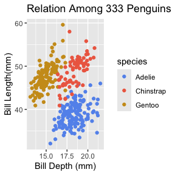

```r
p2a_plot = penguins %>%
  ggplot(aes(x = bill_depth_mm, y = bill_length_mm, color = species)) +
  geom_point() +
  scale_color_manual(values = c("Adelie" = "cornflowerblue", "Chinstrap" = "coral2", "Gentoo" = "goldenrod3")) +
  labs(x = "Bill Depth (mm)",
       y = "Bill Length(mm)",
       title = paste("Relation Among", nrow(penguins), "Penguins"))

p2a_plot
```

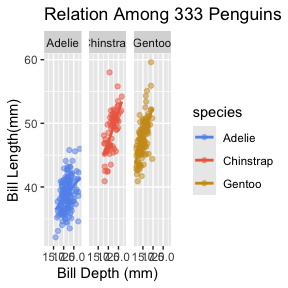

```r
p2b_plot = penguins %>%
  ggplot(aes(x = bill_depth_mm, y = bill_length_mm, color = species)) +
  geom_point(alpha = 0.5) +
  scale_color_manual(values = c("Adelie" = "cornflowerblue", "Chinstrap" = "coral2", "Gentoo" = "goldenrod3")) +
  labs(x = "Bill Depth (mm)",
       y = "Bill Length(mm)",
       title = paste("Relation Among", nrow(penguins), "Penguins")) +
  geom_smooth(method = "lm", se = FALSE) +
  facet_wrap(~ species)

p2b_plot
```

# Problem 3

## Part A

```r
set.seed(0)
result <- generate_random_graph(n = 20,
                                clique_fraction = 0.5,
                                density_low = 0.1)
adj_mat <- result$adj_mat
dim(adj_mat)
```

```
#> [1] 20 20
```

```r
adj_mat[1:5,1:5]
```

```
#>      [,1] [,2] [,3] [,4] [,5]
#> [1,]    1    0    1    0    0
#> [2,]    0    1    1    1    1
#> [3,]    1    1    1    0    0
#> [4,]    0    1    0    1    0
#> [5,]    0    1    0    0    1
```

`generate_random_graph` first checks that the arguments provided by the user are valid, and then creates a random n by n matrix of 1s and 0s, with a density (i.e. proportion of nonzero entries) that the user can also specify. The matrix is then filled with a certain proportion of 1s in the top left, and the order of the entries is randomized again. Then, an array of reversed indices for the matrix is computed, and then both are returned by the function.

## Part B

```r
mat_long = pivot_longer_heatmap(adj_mat)
```

`pivot_longer_heatmap` then takes the matrix returned by `generate_random_graph` and then turns it into a long format. That is, the long format tibble returned by this function will have the original element’s row and column indices in the first 2 rows, and then the value of the element at the corresponding original index (either 1 or 0) in the 3rd column.

## Part C

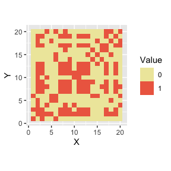

```r
ggplot(data = mat_long, mapping = aes(x = X, y = Y, fill = factor(Value))) +
  geom_tile() +
  scale_fill_manual(values = c("palegoldenrod", "coral2"), labels = c("0", "1")) +
  theme(aspect.ratio = 1) +
  labs(fill = "Value")
```

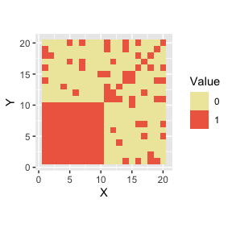

```r
adj_mat2 = result$adj_mat[result$rev_order, result$rev_order]
mat_long2 = pivot_longer_heatmap(adj_mat2)
ggplot(data = mat_long2, mapping = aes(x = X, y = Y, fill = factor(Value))) +
  geom_tile() +
  scale_fill_manual(values = c("palegoldenrod", "coral2"), labels = c("0", "1")) +
  theme(aspect.ratio = 1) +
  labs(fill = "Value")
```

# Problem 4

To ensure this teammate’s function is correct, I would write a few test cases which which I could test the function. The first test case would be a clique density of 1, which would make the entire matrix a clique. I would then write a test case with 0 density, so no clique. Then, my last 2 test cases would just be some test cases of realistic data from adjacency matrices, so just some random values for the clique density between 0 and 1.